# MovieLens Project Question Notebook_MJB

### `Project - MovieLens Data Analysis`

The GroupLens Research Project is a research group in the Department of Computer Science and Engineering at the University of Minnesota. The data is widely used for collaborative filtering and other filtering solutions. However, we will be using this data to act as a means to demonstrate our skill in using Python to “play” with data.

### `Objective:`

- To implement the techniques learnt as a part of the course.

### `Datasets Information:`

*rating.csv:* It contains information on ratings given by the users to a particular movie.

- user id: id assigned to every user
- movie id: id assigned to every movie
- rating: rating given by the user
- timestamp: Time recorded when the user gave a rating

*movie.csv:* File contains information related to the movies and their genre.

- movie id: id assigned to every movie
- movie title: Title of the movie
- release date: Date of release of the movie
- Action: Genre containing binary values (1 - for action 0 - not action)
- Adventure: Genre containing binary values (1 - for adventure 0 - not adventure)
- Animation: Genre containing binary values (1 - for animation 0 - not animation)
- Children’s: Genre containing binary values (1 - for children's 0 - not children's)
- Comedy: Genre containing binary values (1 - for comedy 0 - not comedy)
- Crime: Genre containing binary values (1 - for crime 0 - not crime)
- Documentary: Genre containing binary values (1 - for documentary 0 - not documentary)
- Drama: Genre containing binary values (1 - for drama 0 - not drama)
- Fantasy: Genre containing binary values (1 - for fantasy 0 - not fantasy)
- Film-Noir: Genre containing binary values (1 - for film-noir 0 - not film-noir)
- Horror: Genre containing binary values (1 - for horror 0 - not horror)
- Musical: Genre containing binary values (1 - for musical 0 - not musical)
- Mystery: Genre containing binary values (1 - for mystery 0 - not mystery)
- Romance: Genre containing binary values (1 - for romance 0 - not romance)
- Sci-Fi: Genre containing binary values (1 - for sci-fi 0 - not sci-fi)
- Thriller: Genre containing binary values (1 - for thriller 0 - not thriller)
- War: Genre containing binary values (1 - for war 0 - not war)
- Western: Genre containing binary values (1 - for western - not western)

*user.csv:* It contains information of the users who have rated the movies.

- user id: id assigned to every user
- age: Age of the user
- gender: Gender of the user
- occupation: Occupation of the user
- zip code: Zip code of the use

**`Please provide your insights wherever necessary.`**

### `Learning Outcomes:`

- Exploratory Data Analysis
- Visualization using Python
- Pandas – groupby, merging

### `Domain`

- Internet and Entertainment

**Note that the project will need you to apply the concepts of groupby and merging extensively.**

### 1. Import the necessary packages - 2.5 marks

```python
import numpy as np
import pandas as pd
import seaborn as sns
sns.set(color_codes=True)
import matplotlib.pyplot as plt
%matplotlib inline
```

### 2. Read the 3 datasets into dataframes - 2.5 marks

```python
df_rating = pd.read_csv('Data.csv') #Read in ratings
df_movie = pd.read_csv('item.csv')  #read in movie info
df_user = pd.read_csv('user.csv')       # read in user info
```

### 3. Apply info, shape, describe, and find the number of missing values in the data. Present at least 3 observations from these operations - 2.5 marks

- Note that you will need to do it for all the three datasets seperately

```python
df_rating.info() # information on Ratings
```

```
<class 'pandas.core.frame.DataFrame'>
RangeIndex: 100000 entries, 0 to 99999
Data columns (total 4 columns):
 #   Column     Non-Null Count   Dtype
---  ------     --------------   -----
 0   user id    100000 non-null  int64
 1   movie id   100000 non-null  int64
 2   rating     100000 non-null  int64
 3   timestamp  100000 non-null  int64
dtypes: int64(4)
memory usage: 3.1 MB
```

```python
df_rating.shape  #shape of the ratings data set
```

```
(100000, 4)
```

```python
df_rating.describe() #describe the ratings data set
```

|  | user id | movie id | rating | timestamp |
| --- | --- | --- | --- | --- |
| count | 100000.00000 | 100000.000000 | 100000.000000 | 1.000000e+05 |
| mean | 462.48475 | 425.530130 | 3.529860 | 8.835289e+08 |
| std | 266.61442 | 330.798356 | 1.125674 | 5.343856e+06 |
| min | 1.00000 | 1.000000 | 1.000000 | 8.747247e+08 |
| 25% | 254.00000 | 175.000000 | 3.000000 | 8.794487e+08 |
| 50% | 447.00000 | 322.000000 | 4.000000 | 8.828269e+08 |
| 75% | 682.00000 | 631.000000 | 4.000000 | 8.882600e+08 |
| max | 943.00000 | 1682.000000 | 5.000000 | 8.932866e+08 |

```python
missing_rating=df_rating.isnull().sum().sum() #number of missing in Ratings data set
print("Number of missing ratings is",missing_rating)
```

```
Number of missing ratings is 0
```

```python
df_movie.info() # information on movies data set
```

```
<class 'pandas.core.frame.DataFrame'>
RangeIndex: 1681 entries, 0 to 1680
Data columns (total 22 columns):
 #   Column        Non-Null Count  Dtype
---  ------        --------------  -----
 0   movie id      1681 non-null   int64
 1   movie title   1681 non-null   object
 2   release date  1681 non-null   object
 3   unknown       1681 non-null   int64
 4   Action        1681 non-null   int64
 5   Adventure     1681 non-null   int64
 6   Animation     1681 non-null   int64
 7   Childrens     1681 non-null   int64
 8   Comedy        1681 non-null   int64
 9   Crime         1681 non-null   int64
 10  Documentary   1681 non-null   int64
 11  Drama         1681 non-null   int64
 12  Fantasy       1681 non-null   int64
 13  Film-Noir     1681 non-null   int64
 14  Horror        1681 non-null   int64
 15  Musical       1681 non-null   int64
 16  Mystery       1681 non-null   int64
 17  Romance       1681 non-null   int64
 18  Sci-Fi        1681 non-null   int64
 19  Thriller      1681 non-null   int64
 20  War           1681 non-null   int64
 21  Western       1681 non-null   int64
dtypes: int64(20), object(2)
memory usage: 289.0+ KB
```

```python
df_movie.shape  #shape of the movie data set
```

```
(1681, 22)
```

```python
df_movie.describe() #describe the movie data set
```

|  | movie id | unknown | Action | Adventure | Animation | Childrens | Comedy | Crime | Documentary | Drama | Fantasy | Film-Noir | Horror | Musical | Mystery | Romance | Sci-Fi | Thriller | War | Western |
| --- | --- | --- | --- | --- | --- | --- | --- | --- | --- | --- | --- | --- | --- | --- | --- | --- | --- | --- | --- | --- |
| count | 1681.000000 | 1681.000000 | 1681.000000 | 1681.000000 | 1681.000000 | 1681.000000 | 1681.000000 | 1681.000000 | 1681.000000 | 1681.000000 | 1681.000000 | 1681.000000 | 1681.000000 | 1681.000000 | 1681.000000 | 1681.000000 | 1681.000000 | 1681.000000 | 1681.000000 | 1681.000000 |
| mean | 841.841761 | 0.000595 | 0.149316 | 0.080309 | 0.024985 | 0.072576 | 0.300416 | 0.064842 | 0.029744 | 0.431291 | 0.013087 | 0.014277 | 0.054729 | 0.033314 | 0.036288 | 0.146936 | 0.060083 | 0.149316 | 0.042237 | 0.016062 |
| std | 485.638077 | 0.024390 | 0.356506 | 0.271852 | 0.156126 | 0.259516 | 0.458576 | 0.246321 | 0.169931 | 0.495404 | 0.113683 | 0.118667 | 0.227519 | 0.179507 | 0.187061 | 0.354148 | 0.237712 | 0.356506 | 0.201189 | 0.125751 |
| min | 1.000000 | 0.000000 | 0.000000 | 0.000000 | 0.000000 | 0.000000 | 0.000000 | 0.000000 | 0.000000 | 0.000000 | 0.000000 | 0.000000 | 0.000000 | 0.000000 | 0.000000 | 0.000000 | 0.000000 | 0.000000 | 0.000000 | 0.000000 |
| 25% | 422.000000 | 0.000000 | 0.000000 | 0.000000 | 0.000000 | 0.000000 | 0.000000 | 0.000000 | 0.000000 | 0.000000 | 0.000000 | 0.000000 | 0.000000 | 0.000000 | 0.000000 | 0.000000 | 0.000000 | 0.000000 | 0.000000 | 0.000000 |
| 50% | 842.000000 | 0.000000 | 0.000000 | 0.000000 | 0.000000 | 0.000000 | 0.000000 | 0.000000 | 0.000000 | 0.000000 | 0.000000 | 0.000000 | 0.000000 | 0.000000 | 0.000000 | 0.000000 | 0.000000 | 0.000000 | 0.000000 | 0.000000 |
| 75% | 1262.000000 | 0.000000 | 0.000000 | 0.000000 | 0.000000 | 0.000000 | 1.000000 | 0.000000 | 0.000000 | 1.000000 | 0.000000 | 0.000000 | 0.000000 | 0.000000 | 0.000000 | 0.000000 | 0.000000 | 0.000000 | 0.000000 | 0.000000 |
| max | 1682.000000 | 1.000000 | 1.000000 | 1.000000 | 1.000000 | 1.000000 | 1.000000 | 1.000000 | 1.000000 | 1.000000 | 1.000000 | 1.000000 | 1.000000 | 1.000000 | 1.000000 | 1.000000 | 1.000000 | 1.000000 | 1.000000 | 1.000000 |

```python
missing_movie=df_movie.isnull().sum().sum() #number of missing in movie data set
print("Number of missing items in  movie data is",missing_movie)
```

[output not shown]

```python
df_user.info() # information on user
```

```
<class 'pandas.core.frame.DataFrame'>
RangeIndex: 943 entries, 0 to 942
Data columns (total 5 columns):
 #   Column      Non-Null Count  Dtype
---  ------      --------------  -----
 0   user id     943 non-null    int64
 1   age         943 non-null    int64
 2   gender      943 non-null    object
 3   occupation  943 non-null    object
 4   zip code    943 non-null    object
dtypes: int64(2), object(3)
memory usage: 37.0+ KB
```

```python
df_user.shape  #shape of the ratings data set
```

```
(943, 5)
```

```python
df_user.describe() #describe the user data set
```

|  | user id | age |
| --- | --- | --- |
| count | 943.000000 | 943.000000 |
| mean | 472.000000 | 34.051962 |
| std | 272.364951 | 12.192740 |
| min | 1.000000 | 7.000000 |
| 25% | 236.500000 | 25.000000 |
| 50% | 472.000000 | 31.000000 |
| 75% | 707.500000 | 43.000000 |
| max | 943.000000 | 73.000000 |

```python
missing_user=df_user.isnull().sum().sum() #number of missing in user data set
print("Number of missing user items is",missing_user)
```

```
Number of missing user items is 0
```

**Observations:**

Observation 1: The rating data set has 100,000 observations. The scale goes from 1 to 5. The mean rating is 3.53 and median is 4.0. This means that the data set is slightly left skewed

### 4. Find the number of movies per genre using the item data - 2.5 marks

```python
genre_df=df_movie.copy().drop(['movie id','movie title', 'release date'], axis=1) #remove none genre columns

genre_df.sum().sort_values(ascending=False) # Returns numbers of movies per genre
```

```
Drama          725
Comedy         505
Thriller       251
Action         251
Romance        247
Adventure      135
Childrens      122
Crime          109
Sci-Fi         101
Horror          92
War             71
Mystery         61
Musical         56
Documentary     50
Animation       42
Western         27
Film-Noir       24
Fantasy         22
unknown          1
dtype: int64
```

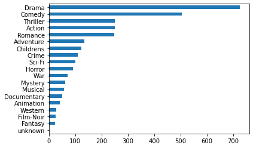

```python
genre_df.sum().sort_values(ascending=True).plot(kind='barh'); #plots number of movies per genre
```

**Insights:**

Drama and Comedy are overwhelming top genres. Fantasy and Film-Noir are least common genres

### 5. Drop the movie where the genre is unknown - 2.5 marks

```python
df_movie[df_movie.unknown!=0] # review movies that are tagged as unknown
```

|  | movie id | movie title | release date | unknown | Action | Adventure | Animation | Childrens | Comedy | Crime | ... | Fantasy | Film-Noir | Horror | Musical | Mystery | Romance | Sci-Fi | Thriller | War | Western |
| --- | --- | --- | --- | --- | --- | --- | --- | --- | --- | --- | --- | --- | --- | --- | --- | --- | --- | --- | --- | --- | --- |
| 1371 | 1373 | Good Morning | 4-Feb-1971 | 1 | 0 | 0 | 0 | 0 | 0 | 0 | ... | 0 | 0 | 0 | 0 | 0 | 0 | 0 | 0 | 0 | 0 |

1 rows × 22 columns

```python
df_movie = df_movie[df_movie.unknown!=1] #remove the unknown movies from movie data set
```

**Insights:**

There was one movie that was unknown. This movie was "Good Morning" that was released in 1971

### 6. Find the movies that have more than one genre - 5 marks

hint: use sum on the axis = 1

Display movie name, number of genres for the movie in dataframe

and also print(total number of movies which have more than one genres)

```python
# Creating a dataframe with the movie name and number of genres for movies
df_movie_genre_num=df_movie.drop(columns=['movie id', 'release date'], inplace=False).groupby(by='movie title').sum().sum(axis=1).to_frame(name="number of genres")
df_movie_genre_num
```

| movie title | number of genres |
| --- | --- |
| 'Til There Was You | 2 |
| 1-900 | 1 |
| 101 Dalmatians | 2 |
| 12 Angry Men | 1 |
| 187 | 1 |
| ... | ... |
| Young Guns | 3 |
| Young Guns II | 3 |
| Young Poisoner's Handbook, The | 1 |
| Zeus and Roxanne | 1 |
| Á köldum klaka (Cold Fever) | 2 |

1658 rows × 1 columns

```python
total_movies_gt_1genre =df_movie_genre_num[df_movie_genre_num['number of genres']>1].count()

print('total number of movies which have more than one genres is ',total_movies_gt_1genre)
```

```
total number of movies which have more than one genres is  number of genres    848
dtype: int64
```

**Insights:**

Over 50% of the movies have more than one genre

### 7. Univariate plots of columns: 'rating', 'Age', 'release year', 'Gender' and 'Occupation' - 10 marks

*HINT: Use distplot for age and countplot for release year, ratings,*

*HINT: Please refer to the below snippet to understand how to get to release year from release date. You can use str.split() as depicted below or you could convert it to pandas datetime format and extract year (.dt.year)*

```python
a = 'My*cat*is*brown'
print(a.split('*')[3])

#similarly, the release year needs to be taken out from release date

#also you can simply slice existing string to get the desired data, if we want to take out the colour of the cat

print(a[10:])
print(a[-5:])
```

```
brown
brown
brown
```

```python
df_movie['release year'] = pd.to_datetime(df_movie['release date']).dt.to_period('Y') #extract year from release date
```

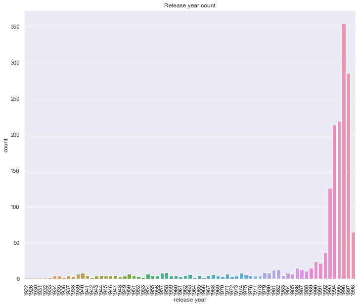

```python
plt.figure(figsize=(12,10))
plt.xticks(rotation=90)
ax=sns.countplot(df_movie['release year'].sort_values(ascending=True))
ax.set_title('Release year count');
```

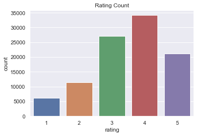

```python
ax=sns.countplot(df_rating['rating'].sort_values(ascending=True))
ax.set_title('Rating Count');
```

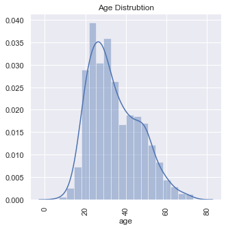

```python
plt.figure(figsize=(5,5))
plt.xticks(rotation=90)
ax=sns.distplot(df_user['age'].sort_values(ascending=True))
ax.set_title('Age Distrubtion');
```

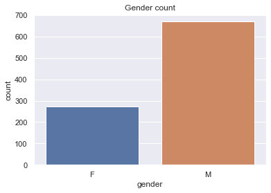

```python
#Create bar chart for Gender
ax=sns.countplot(df_user['gender'].sort_values(ascending=True))
ax.set_title('Gender count');
```

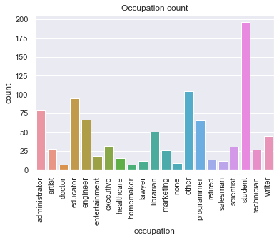

```python
#Create bar chart for Occupation
plt.xticks(rotation=90)
ax=sns.countplot(df_user['occupation'].sort_values(ascending=True))
ax.set_title('Occupation count');
```

### 8. Visualize how popularity of genres has changed over the years - 10 marks

Note that you need to use the **percent of number of releases in a year** as a parameter of popularity of a genre

Hint 1: You need to reach to a data frame where the release year is the index and the genre is the column names (one cell shows the number of release in a year in one genre) or vice versa. (Drop unnecessary column if there are any)

Hint 2: Find the total number of movies release in a year(use item dataset to get count of movies released in a particular year, store that value in a new column as 'total'). Now divide the value of each genre in that year by total to get percentage number of release in a particular year. `(df.div(df['total'], axis= 0) * 100)`

Once that is achieved, you can either use univariate plots or can use the heatmap to visualise all the changes over the years in one go.

Hint 3: Use groupby on the relevant column and use sum() on the same to find out the number of releases in a year/genre.

```python
df_movie2 = df_movie.drop(columns=['movie id', 'release date','movie title'], inplace=False)
df_movie2.set_index('release year',inplace=True) #setting release year to index
```

```python
df_movie3=df_movie2.groupby(by='release year').sum() #create sum by genre by year
df_movie3
```

| release year | unknown | Action | Adventure | Animation | Childrens | Comedy | Crime | Documentary | Drama | Fantasy | Film-Noir | Horror | Musical | Mystery | Romance | Sci-Fi | Thriller | War | Western |
| --- | --- | --- | --- | --- | --- | --- | --- | --- | --- | --- | --- | --- | --- | --- | --- | --- | --- | --- | --- |
| 1922 | 0 | 0 | 0 | 0 | 0 | 0 | 0 | 0 | 0 | 0 | 0 | 1 | 0 | 0 | 0 | 0 | 0 | 0 | 0 |
| 1926 | 0 | 0 | 0 | 0 | 0 | 0 | 0 | 0 | 1 | 0 | 0 | 0 | 0 | 0 | 0 | 0 | 0 | 0 | 0 |
| 1930 | 0 | 0 | 0 | 0 | 0 | 0 | 0 | 0 | 1 | 0 | 0 | 0 | 0 | 0 | 0 | 0 | 0 | 0 | 0 |
| 1931 | 0 | 0 | 0 | 0 | 0 | 0 | 1 | 0 | 0 | 0 | 1 | 0 | 0 | 0 | 0 | 0 | 1 | 0 | 0 |
| 1932 | 0 | 0 | 0 | 0 | 0 | 0 | 0 | 0 | 0 | 0 | 0 | 0 | 0 | 0 | 1 | 0 | 0 | 1 | 0 |
| ... | ... | ... | ... | ... | ... | ... | ... | ... | ... | ... | ... | ... | ... | ... | ... | ... | ... | ... | ... |
| 1994 | 0 | 30 | 13 | 4 | 15 | 82 | 8 | 9 | 97 | 3 | 0 | 8 | 2 | 2 | 35 | 7 | 25 | 7 | 6 |
| 1995 | 0 | 40 | 22 | 6 | 21 | 63 | 11 | 5 | 89 | 3 | 1 | 14 | 3 | 5 | 37 | 15 | 39 | 5 | 2 |
| 1996 | 0 | 44 | 24 | 9 | 21 | 108 | 21 | 18 | 170 | 6 | 1 | 11 | 9 | 6 | 38 | 15 | 47 | 9 | 2 |
| 1997 | 0 | 46 | 20 | 3 | 22 | 87 | 30 | 6 | 113 | 4 | 2 | 8 | 5 | 18 | 51 | 13 | 54 | 14 | 0 |
| 1998 | 0 | 12 | 3 | 0 | 1 | 13 | 7 | 3 | 33 | 1 | 2 | 4 | 1 | 3 | 11 | 5 | 18 | 0 | 0 |

71 rows × 19 columns

```python
    #Counting individual movies per year then adding total column the sum genre by year data set

    df_movie3['total']=df_movie[['movie id','release year']].groupby(by='release year').count().rename(columns={'movie id':'total'})
```

```python
df_movie4=df_movie3.div(df_movie3['total'], axis= 0) * 100 #creating percents
```

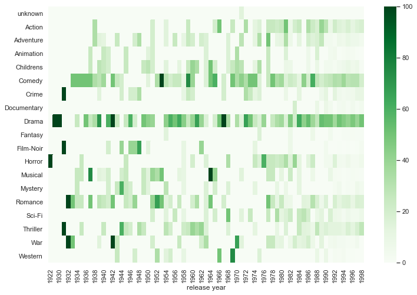

```python
#Creating a heatmap of the percent of movies per genre per year

plt.figure(figsize=(12,8))

sns.heatmap(df_movie4.drop(columns=['total']).T,cmap="Greens")
```

### 9. Find the top 25 movies in terms of average ratings for movies that have been rated more than 100 times - 10 marks

Hints :

1. Find the count of ratings and average ratings for every movie.
2. Slice the movies which have ratings more than 100.
3. Sort values according to average rating such that movie which highest rating is on top.
4. Select top 25 movies.
5. You will have to use the .merge() function to get the movie titles.

Note: This question will need you to research about groupby and apply your findings. You can find more on groupby on https://realpython.com/pandas-groupby/.

```python
# sorting the movies by ratings
df_rating_cnt=df_rating[['movie id','user id']].groupby('movie id').count().rename(columns = {'user id':'Rating Count'}).sort_values('Rating Count',ascending=False)
df_rating_cnt
```

| movie id | Rating Count |
| --- | --- |
| 50 | 583 |
| 258 | 509 |
| 100 | 508 |
| 181 | 507 |
| 294 | 485 |
| ... | ... |
| 1576 | 1 |
| 1577 | 1 |
| 1348 | 1 |
| 1579 | 1 |
| 1682 | 1 |

1682 rows × 1 columns

```python
df_rating_gb=df_rating[['movie id','rating']].groupby('movie id')
df_rating_cnt=df_rating_gb.count().rename(columns={'rating':'rating count'})
df_rating_mean=df_rating_gb.mean().rename(columns={'rating':'rating average'})

df_rating_cnt_avg=df_rating_cnt.join(df_rating_mean,how='inner').sort_values('rating count',ascending=False)
```

```python
df_rating_cnt_avg
```

| movie id | rating count | rating average |
| --- | --- | --- |
| 50 | 583 | 4.358491 |
| 258 | 509 | 3.803536 |
| 100 | 508 | 4.155512 |
| 181 | 507 | 4.007890 |
| 294 | 485 | 3.156701 |
| ... | ... | ... |
| 1576 | 1 | 1.000000 |
| 1577 | 1 | 1.000000 |
| 1348 | 1 | 1.000000 |
| 1579 | 1 | 1.000000 |
| 1682 | 1 | 3.000000 |

1682 rows × 2 columns

```python
#Selecting the movies with the best average ratings and have over 100 ratings

Filter_count_gtr_100 = df_rating_cnt_avg['rating count'] >100
df_top_25=df_rating_cnt_avg[Filter_count_gtr_100].nlargest(25,'rating average')
```

```python
#combining rating counts and average rating
print("Top rated movies with at least 100 ratings")
pd.merge(df_top_25,df_movie,how="inner",on='movie id')[['movie title','rating count','movie id','rating average']]
```

```
Top rated movies with at least 100 ratings
```

|  | movie title | rating count | movie id | rating average |
| --- | --- | --- | --- | --- |
| 0 | Close Shave, A | 112 | 408 | 4.491071 |
| 1 | Schindler's List | 298 | 318 | 4.466443 |
| 2 | Wrong Trousers, The | 118 | 169 | 4.466102 |
| 3 | Casablanca | 243 | 483 | 4.456790 |
| 4 | Shawshank Redemption, The | 283 | 64 | 4.445230 |
| 5 | Rear Window | 209 | 603 | 4.387560 |
| 6 | Usual Suspects, The | 267 | 12 | 4.385768 |
| 7 | Star Wars | 583 | 50 | 4.358491 |
| 8 | 12 Angry Men | 125 | 178 | 4.344000 |
| 9 | Citizen Kane | 198 | 134 | 4.292929 |
| 10 | To Kill a Mockingbird | 219 | 427 | 4.292237 |
| 11 | One Flew Over the Cuckoo's Nest | 264 | 357 | 4.291667 |
| 12 | Silence of the Lambs, The | 390 | 98 | 4.289744 |
| 13 | North by Northwest | 179 | 480 | 4.284916 |
| 14 | Godfather, The | 413 | 127 | 4.283293 |
| 15 | Secrets & Lies | 162 | 285 | 4.265432 |
| 16 | Good Will Hunting | 198 | 272 | 4.262626 |
| 17 | Manchurian Candidate, The | 131 | 657 | 4.259542 |
| 18 | Dr. Strangelove or: How I Learned to Stop Worr... | 194 | 474 | 4.252577 |
| 19 | Raiders of the Lost Ark | 420 | 174 | 4.252381 |
| 20 | Vertigo | 179 | 479 | 4.251397 |
| 21 | Titanic | 350 | 313 | 4.245714 |
| 22 | Lawrence of Arabia | 173 | 511 | 4.231214 |
| 23 | Maltese Falcon, The | 138 | 484 | 4.210145 |
| 24 | Empire Strikes Back, The | 367 | 172 | 4.204360 |

### 10. Check for the validity of the below statements with respect to the data provided - 10 marks

- Men watch more drama than women
- Women watch more Sci-Fi than men
- Men watch more Romance than women

**compare the percentages**

**Please pay attention to what should be the denominator while calculating percentages**

1. Merge all the datasets
2. There is no need to conduct statistical tests around this. Just **compare the percentages** and comment on the validity of the above statements.
3. you might want ot use the .sum(), .div() function here.
4. Use number of ratings to validate the numbers. For example, if out of 4000 ratings received by women, 3000 are for drama, we will assume that 75% of the women watch drama.

```python
# Merging all the data sets
df_rating_movie =pd.merge(df_rating,df_movie,how='left',on='movie id')# add movie attributes
df_rating_movie_user = pd.merge(df_rating_movie,df_user,how='left',on="user id") #add user attributes
df_rating_movie_user.sample(5)
```

|  | user id | movie id | rating | timestamp | movie title | release date | unknown | Action | Adventure | Animation | ... | Romance | Sci-Fi | Thriller | War | Western | release year | age | gender | occupation | zip code |
| --- | --- | --- | --- | --- | --- | --- | --- | --- | --- | --- | --- | --- | --- | --- | --- | --- | --- | --- | --- | --- | --- |
| 75550 | 186 | 1213 | 3 | 879023882 | Guilty as Sin | 01-Jan-1993 | 0.0 | 0.0 | 0.0 | 0.0 | ... | 0.0 | 0.0 | 1.0 | 0.0 | 0.0 | 1993 | 39 | F | executive | 00000 |
| 34780 | 560 | 25 | 3 | 879976706 | Birdcage, The | 08-Mar-1996 | 0.0 | 0.0 | 0.0 | 0.0 | ... | 0.0 | 0.0 | 0.0 | 0.0 | 0.0 | 1996 | 32 | M | student | 10003 |
| 25886 | 475 | 100 | 5 | 891452276 | Fargo | 14-Feb-1997 | 0.0 | 0.0 | 0.0 | 0.0 | ... | 0.0 | 0.0 | 1.0 | 0.0 | 0.0 | 1997 | 30 | M | programmer | 75230 |
| 77473 | 936 | 116 | 4 | 886832636 | Cold Comfort Farm | 23-Apr-1996 | 0.0 | 0.0 | 0.0 | 0.0 | ... | 0.0 | 0.0 | 0.0 | 0.0 | 0.0 | 1996 | 24 | M | other | 32789 |
| 67092 | 830 | 2 | 3 | 891561806 | GoldenEye | 01-Jan-1995 | 0.0 | 1.0 | 1.0 | 0.0 | ... | 0.0 | 0.0 | 1.0 | 0.0 | 0.0 | 1995 | 46 | M | programmer | 53066 |

5 rows × 30 columns

```python
#Create a group by object for gender
by_gender=df_rating_movie_user.groupby('gender')
```

```python
# Review statement men watch more drama than women
df_by_gender_drama_sum=by_gender['Drama'].sum().to_frame(name='drama sum')
df_by_gender_rating_count=by_gender['rating'].count().to_frame(name='rating count')
df_by_gender_drama=pd.merge(df_by_gender_drama_sum,df_by_gender_rating_count,how='left',on='gender')
df_by_gender_drama['drama sum'].div(df_by_gender_drama['rating count'], axis= 0) * 100
```

```
gender
F    42.766123
M    38.899811
dtype: float64
```

```python
# Review statement Women watch more Sci-Fi than men
df_by_gender_scifi_sum=by_gender['Sci-Fi'].sum().to_frame(name='sci-fi sum')
df_by_gender_rating_count=by_gender['rating'].count().to_frame(name='rating count')
df_by_gender_scifi=pd.merge(df_by_gender_scifi_sum,df_by_gender_rating_count,how='left',on='gender')
df_by_gender_scifi['sci-fi sum'].div(df_by_gender_drama['rating count'], axis= 0) * 100
```

```
gender
F    10.213675
M    13.602208
dtype: float64
```

```python
# Review statement Men watch more Romance than women
df_by_gender_romance_sum=by_gender['Romance'].sum().to_frame(name='romance sum')
df_by_gender_rating_count=by_gender['rating'].count().to_frame(name='rating count')
df_by_gender_romance=pd.merge(df_by_gender_romance_sum,df_by_gender_rating_count,how='left',on='gender')
df_by_gender_romance['romance sum'].div(df_by_gender_drama['rating count'], axis= 0) * 100
```

```
gender
F    22.758353
M    18.318072
dtype: float64
```

**Conclusion:** The statement men watch more drama than women is false. Women watch dramas 42.8% of time compared to 38.9% of time for Men

The statement women watch more Sci-Fi than men is false. Women watch Sci-Fi 10.2% of time compared to 13.6% of time for Men

The statement men watch more Romance than women is false. Women watch Romance 22.8% of time compared to 18.3% of time for Men